# Practical Machine Learning Assignment

Kateryna Kyrpa

06 10 2020

## Background

Using devices such as Jawbone Up, Nike FuelBand, and Fitbit it is now possible to collect a large amount of data about personal activity relatively inexpensively. These type of devices are part of the quantified self movement – a group of enthusiasts who take measurements about themselves regularly to improve their health, to find patterns in their behavior, or because they are tech geeks. One thing that people regularly do is quantify how much of a particular activity they do, but they rarely quantify how well they do it. In this project, your goal will be to use data from accelerometers on the belt, forearm, arm, and dumbell of 6 participants. They were asked to perform barbell lifts correctly and incorrectly in 5 different ways. More information is available from the website here: http://groupware.les.inf.puc-rio.br/har (see the section on the Weight Lifting Exercise Dataset).

## Data Loading and packages

The training data for this project are available here: https://d396qusza40orc.cloudfront.net/predmachlearn/pml-training.csv

The test data are available here: https://d396qusza40orc.cloudfront.net/predmachlearn/pml-testing.csv

First we need to load some required libraries.

```r
library(lattice)
library(ggplot2)
library(caret)
library(rpart)
library(rpart.plot)
library(randomForest)
```

Next step is loading the data and cleansing.

```r
setwd("E:/DataScience/PML")
training_data <- read.csv('pml-training.csv', na.strings = c("NA", "#DIV/0!", ""))
testing_data <- read.csv('pml-testing.csv', na.strings = c("NA", "#DIV/0!", ""))
```

```r
training_data <- training_data[,colSums(is.na(training_data)) == 0]
testing_data <- testing_data[,colSums(is.na(testing_data)) == 0]
clnColumnIndex <- colSums(is.na(training_data))/nrow(training_data) < 0.95
clean_training_data <- training_data[,clnColumnIndex]
dim(training_data)
```

```
## [1] 19622    60
```

```r
dim(testing_data)
```

```
## [1] 20 60
```

## Partitioning of the training data into training set and cross validation set

```r
train_part <- createDataPartition(training_data$classe, p = 0.75, list = FALSE)
training <- training_data[train_part,]
testing <- training_data[-train_part,]
dim(training)
```

```
## [1] 14718    60
```

```r
dim(testing)
```

```
## [1] 4904   60
```

Seems like first 7 variables can be removed as they are non-numerical.

```r
training <- training[,-c(1:7)]
testing <- testing[,-c(1:7)]

ordernames <- names(training)
testing <- testing[,ordernames[1:53]]
dim(training)
```

```
## [1] 14718    53
```

```r
dim(testing)
```

```
## [1] 4904   53
```

## Models

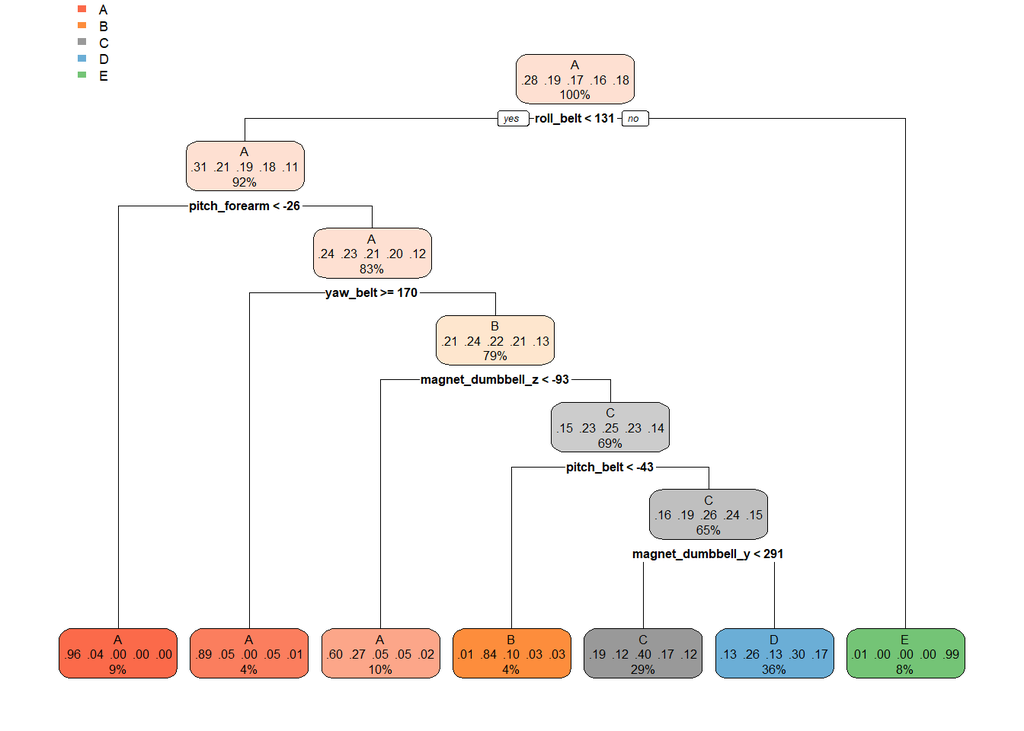

```r
set.seed(127)
DTM <- train(classe ~ ., data = training, method = 'rpart')
RF <- train(classe ~ ., data = training, method = 'rf', ntree = 100)

rpart.plot(DTM$finalModel)
```

### Fitting and prediction

```r
DTM_predict <- predict(DTM, testing)
confusionMatrix(table(testing$classe,DTM_predict))
```

```
## Confusion Matrix and Statistics
##
##    DTM_predict
##       A   B   C   D   E
##   A 863   3 262 263   4
##   B 188 154 159 448   0
##   C  21  14 568 252   0
##   D  46   5 235 518   0
##   E  10   3 183 300 405
##
## Overall Statistics
##
##                Accuracy : 0.5114
##                  95% CI : (0.4973, 0.5255)
##     No Information Rate : 0.3632
##     P-Value [Acc > NIR] : < 2.2e-16
##
##                   Kappa : 0.3913
##
##  Mcnemar's Test P-Value : < 2.2e-16
##
## Statistics by Class:
##
##                      Class: A Class: B Class: C Class: D Class: E
## Sensitivity            0.7651   0.8603   0.4037   0.2908  0.99022
## Specificity            0.8591   0.8317   0.9179   0.9084  0.88966
## Pos Pred Value         0.6186   0.1623   0.6643   0.6443  0.44950
## Neg Pred Value         0.9245   0.9937   0.7928   0.6920  0.99900
## Prevalence             0.2300   0.0365   0.2869   0.3632  0.08340
## Detection Rate         0.1760   0.0314   0.1158   0.1056  0.08259
## Detection Prevalence   0.2845   0.1935   0.1743   0.1639  0.18373
## Balanced Accuracy      0.8121   0.8460   0.6608   0.5996  0.93994
```

```r
RF_predict <- predict(RF, testing)
confusionMatrix(table(testing$classe,RF_predict))
```

```
## Confusion Matrix and Statistics
##
##    RF_predict
##        A    B    C    D    E
##   A 1394    1    0    0    0
##   B    8  937    4    0    0
##   C    0    3  848    4    0
##   D    0    0    4  800    0
##   E    0    0    1    1  899
##
## Overall Statistics
##
##                Accuracy : 0.9947
##                  95% CI : (0.9922, 0.9965)
##     No Information Rate : 0.2859
##     P-Value [Acc > NIR] : < 2.2e-16
##
##                   Kappa : 0.9933
##
##  Mcnemar's Test P-Value : NA
##
## Statistics by Class:
##
##                      Class: A Class: B Class: C Class: D Class: E
## Sensitivity            0.9943   0.9957   0.9895   0.9938   1.0000
## Specificity            0.9997   0.9970   0.9983   0.9990   0.9995
## Pos Pred Value         0.9993   0.9874   0.9918   0.9950   0.9978
## Neg Pred Value         0.9977   0.9990   0.9978   0.9988   1.0000
## Prevalence             0.2859   0.1919   0.1748   0.1642   0.1833
## Detection Rate         0.2843   0.1911   0.1729   0.1631   0.1833
## Detection Prevalence   0.2845   0.1935   0.1743   0.1639   0.1837
## Balanced Accuracy      0.9970   0.9964   0.9939   0.9964   0.9998
```

## Conclusion

```r
predict(RF, testing_data)
```

```
##  [1] B A B A A E D B A A B C B A E E A B B B
## Levels: A B C D E
```